# Projet Mixture model : MNIST

#Binome: - Wacim BELAHCEL - Imad Oualid KACIMI

```r
library(R.matlab)
library(Factoshiny)
library(NbClust)
library(Rmixmod)
library(mclust)
```

# Q1 : Introduction table de donnée

Mnist5 est un dataset qui est un sous ensemble du dataset MNIST contenant 10 classes, chaque individu représente un chiffre écris à la main, et chaque variable represente un pixel.

```r
mnist = readMat(con="C:\\Users\\GIGABYTE\\Downloads\\DATA_MATLAB - Projet-master-MLDS\\DATA_MATLAB - Projet-master-MLDS\\MNIST5.mat")
```

```r
y_data = as.data.frame(mnist$y)
x_data = as.data.frame(mnist$X)
#x_test_data = as.data.frame(mnist$testX)
#y_test_data = as.data.frame(mnist$testY)
```

```r
x_data$y = as.factor(t(y_data))
#Factoshiny(x_data)
```

# Question 2: ACP

Depuis le graph des individus, on remarque que les classes sont trés mélangé et qu’il est difficile de les séparé, mis à part pour la classe y_1 qui semble se démarquer et contribuer fortement à la création de l’axe 1.

Lorsque l’on représente uniquement les modalité de la variable cible y, on peut confirmer notre précedente observation pour y_1, on peut ausi remarquer que y_2 semble contribuer fortement à l’axe 1.

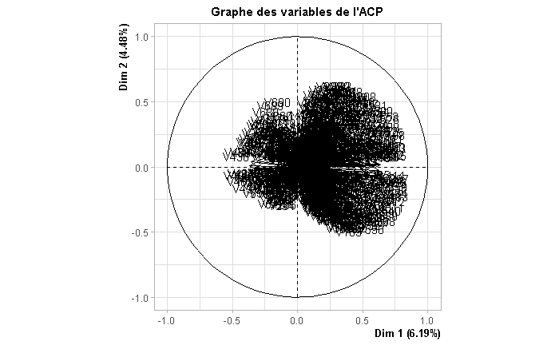

```r
res.PCA<-PCA(x_data,quali.sup=c(785),graph=FALSE)
plot.PCA(res.PCA,choix='var',title="Graphe des variables de l'ACP")
```

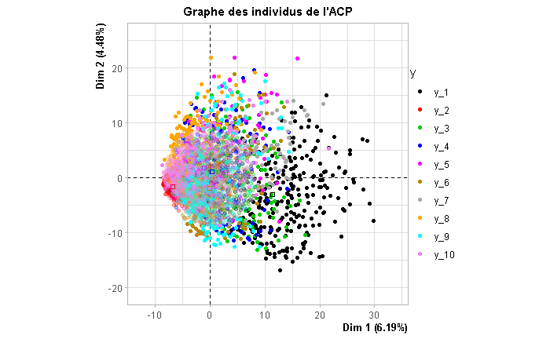

```r
plot.PCA(res.PCA,invisible=c('ind.sup'),select='contrib  726',habillage=785,title="Graphe des individus de l'ACP",label =c('quali'))
```

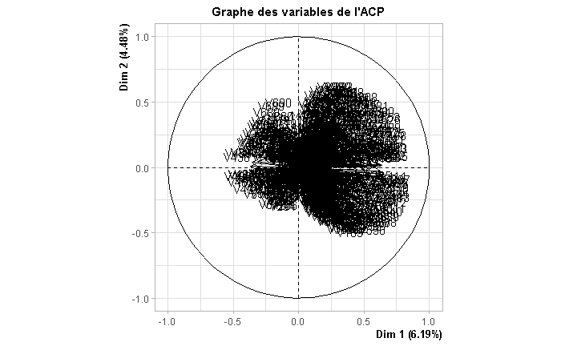

```r
res.PCA<-PCA(x_data,quali.sup=c(785),graph=FALSE)
plot.PCA(res.PCA,choix='var',title="Graphe des variables de l'ACP")
```

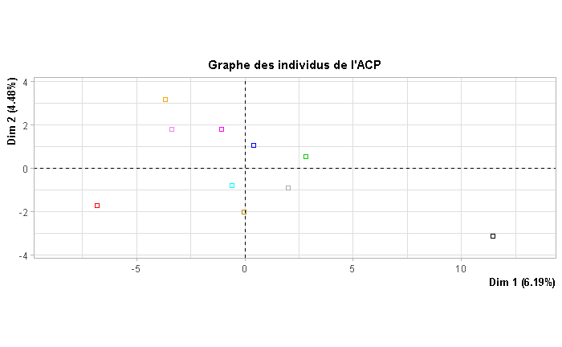

```r
plot.PCA(res.PCA,invisible=c('ind','ind.sup'),habillage=785,title="Graphe des individus de l'ACP",label =c('quali'))
```

# Q4: Clustering Kmean / CAH

La plus part des algorithme ne trouvent que 2 classes en tant que nombre optimal lorsque nous appliquons un clustering, nous pouvons donc proposer 2 classes dans ce cas la, on remarque que la separation est similaire à notre analyse precedente ou nous avions pu voir que seul les points de la classe 0 sont réelement séparable du reste.

```r
res_cah_ward <-NbClust(x_data[,1:784], distance = "euclidean", min.nc=2, max.nc=10, method = "ward.D2",
index = "ch")
res_cah_average<-NbClust(x_data[,1:784], distance = "euclidean", min.nc=2, max.nc=10, method = "average",
index = "ch")
res_cah_complete <-NbClust(x_data[,1:784], distance = "euclidean", min.nc=2, max.nc=10, method = "complete",
index = "ch")
res_cah_single <-NbClust(x_data[,1:784], distance = "euclidean", min.nc=2, max.nc=10, method = "single",
index = "ch")
res_cah_kmeans <-NbClust(x_data[,1:784], distance = "euclidean", min.nc=2, max.nc=10, method = "kmeans",
index = "ch")
```

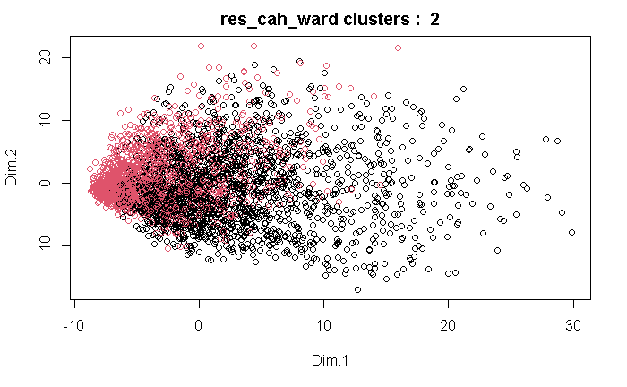

```r
plot(res.PCA$ind$coord,col=res_cah_ward$Best.partition, main = paste("res_cah_ward clusters : ",length(unique(res_cah_ward$Best.partition))))
```

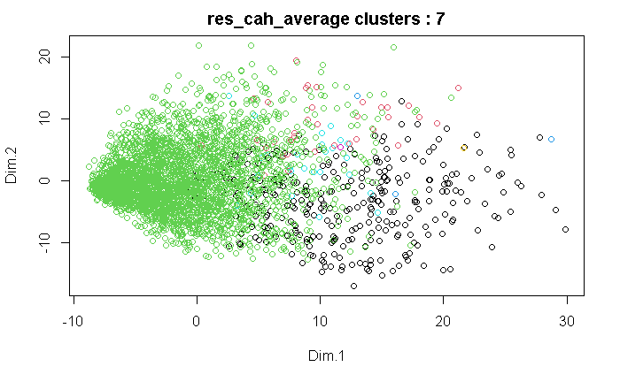

```r
plot(res.PCA$ind$coord,col=res_cah_average$Best.partition, main = paste("res_cah_average clusters :",length(unique(res_cah_average$Best.partition))))
```

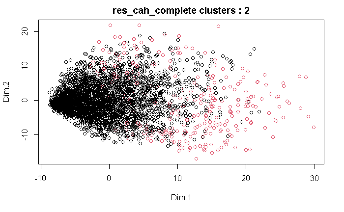

```r
plot(res.PCA$ind$coord,col=res_cah_complete$Best.partition,  main = paste("res_cah_complete clusters :",length(unique(res_cah_complete$Best.partition))))
```

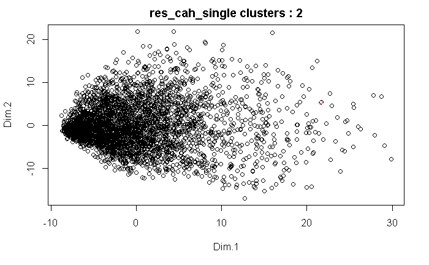

```r
plot(res.PCA$ind$coord,col=res_cah_single$Best.partition, main = paste("res_cah_single clusters :",length(unique(res_cah_single$Best.partition))))
```

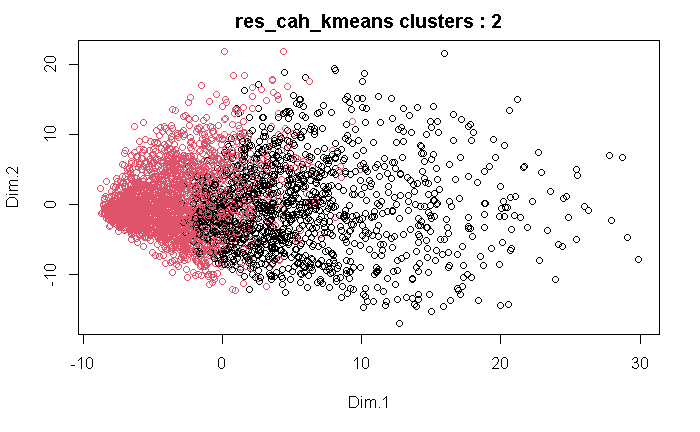

```r
plot(res.PCA$ind$coord,col=res_cah_kmeans$Best.partition, main = paste("res_cah_kmeans clusters :",length(unique(res_cah_kmeans$Best.partition))))
```

# Q5 : HCPC

En observant aussi le graph de l’inertie, on peut confirmer que nous avons un coude au niveau de la 3 éme barre. on peut donc proposer 3 classes.

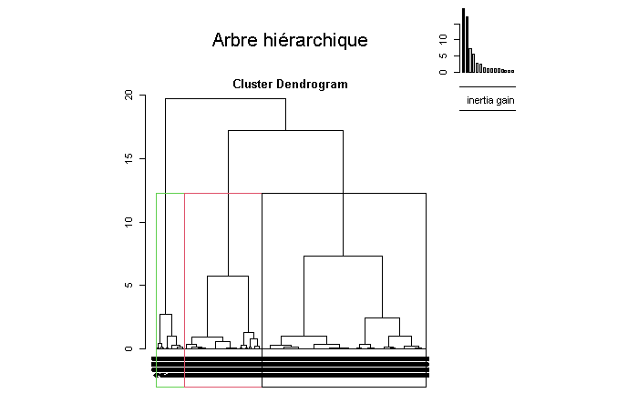

```r
res.PCA<-PCA(x_data,ncp=2,quali.sup=c(785),graph=FALSE)
res.HCPC<-HCPC(res.PCA,nb.clust=3,consol=FALSE,graph=FALSE)
plot.HCPC(res.HCPC,choice='tree',title='Arbre hiérarchique')
```

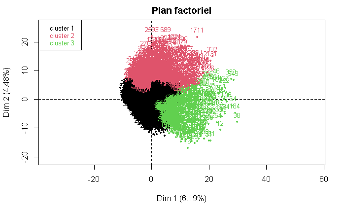

```r
plot.HCPC(res.HCPC,choice='map',draw.tree=FALSE,title='Plan factoriel')
```

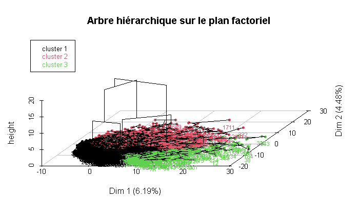

```r
plot.HCPC(res.HCPC,choice='3D.map',ind.names=TRUE,centers.plot=FALSE,angle=60,title='Arbre hiérarchique sur le plan factoriel')
```

# Q6 : comparaison avec HCPC

```r
table(as.vector(res.HCPC$data.clust[,"clust"]),as.vector(res_cah_ward$Best.partition))
```

```
       1    2
  1 1018 1106
  2  577  421
  3  361   12
```

```r
table(as.vector(res.HCPC$data.clust[,"clust"]),as.vector(res_cah_kmeans$Best.partition))
```

```
       1    2
  1  582 1542
  2  417  581
  3  367    6
```

```r
table(as.vector(res.HCPC$data.clust[,"clust"]),as.vector(res_cah_complete$Best.partition))
```

```
       1    2
  1 2106   18
  2  916   82
  3  195  178
```

```r
table(as.vector(res.HCPC$data.clust[,"clust"]),as.vector(res_cah_single$Best.partition))
```

```
       1    2
  1 2124    0
  2  998    0
  3  372    1
```

```r
table(as.vector(res.HCPC$data.clust[,"clust"]),as.vector(res_cah_average$Best.partition))
```

```
       1    2    3    4    5    6    7
  1   50    2 2067    0    5    0    0
  2   40   33  907    1   16    1    0
  3  221    0  144    2    5    0    1
```

# Q7 : MCLUST et RMIXMOD

```r
set.seed(1)
res.PCA<-PCA(x_data,ncp=8,quali.sup=c(785),graph=FALSE)

res.mclust=Mclust(res.PCA$ind$coord,G = 1:10)
```

```
fitting ...
```

```r
summary(res.mclust$BIC)
```

```
Best BIC values:
            VVV,10       VEV,10        VVV,8
BIC      -144242.1 -144610.2142 -145191.0352
BIC diff       0.0    -368.1287    -948.9498
```

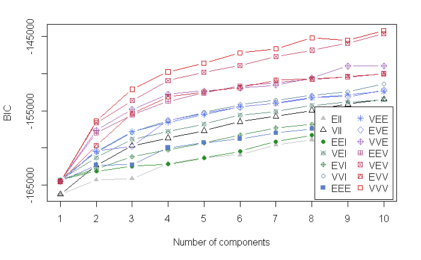

```r
plot(res.mclust,what="BIC")
```

```r
names(res.mclust)
```

```
 [1] "call"           "data"           "modelName"      "n"              "d"              "G"
 [7] "BIC"            "loglik"         "df"             "bic"            "icl"            "hypvol"
[13] "parameters"     "z"              "classification" "uncertainty"
```

```r
table(res.mclust$class,as.vector(y_data[,1]))
```

```
       1   2   3   4   5   6   7   8   9  10
  1    0   1  36  24  60  14   2  96  37  27
  2    0 163   0   0   0   0   0   1   2   0
  3   55   3   5 203   0 116   5   0  55   5
  4    2  29  21  50  11 136   3  28 223  17
  5    2   1   2   0   2   3 228   0   1   0
  6    0   5   2   8 156   1   1  12   1 176
  7    0 184   0   0   0   0   0   0   0   1
  8   29   6 268  65   8  25  14   1   8   2
  9  257   0  15   4   9  12  90   1  11   1
  10   0   1   0   3  95   8   0 225   3 118
```

```r
res.mclust$modelName
```

```
[1] "VVV"
```

```r
adjustedRandIndex(res.mclust$class,as.vector(y_data[,1]))
```

```
[1] 0.35312
```

```r
res.mixmod = mixmodCluster(data=as.data.frame(res.PCA$ind$coord),nbCluster=1:10,models=mixmodGaussianModel(listModels = c("Gaussian_p_Lk_Ck", "Gaussian_pk_Lk_Ck")))
```

```r
summary(res.mixmod)
```

```
* Number of samples    =  3495
* Problem dimension    =  8
*       Number of cluster =  10
*              Model Type =  Gaussian_p_Lk_Ck
*               Criterion =  BIC(144391.2015)
*              Parameters =  list by cluster
*                  Cluster  1 :
                         Proportion =  0.1000
                              Means =  11.6604 -1.1080 1.4701 -1.5900 -2.1913 -3.4260 1.4271 -0.0489
                          Variances = |    39.9447    -2.4758     8.5923     4.2386   -21.5762    -1.4876     5.3444     0.2444 |
                                      |    -2.4758    38.9247   -12.9494   -15.7577    -5.3844     1.6879    17.3352    -4.4352 |
                                      |     8.5923   -12.9494    12.1363     6.8140    -6.9161    -1.2105    -5.3772     1.0393 |
                                      |     4.2386   -15.7577     6.8140    29.3402     1.2453    -4.7256    -7.6150    -0.1890 |
                                      |   -21.5762    -5.3844    -6.9161     1.2453    42.5975     1.6141    -1.8367     5.8522 |
                                      |    -1.4876     1.6879    -1.2105    -4.7256     1.6141     6.1303    -0.6316     1.8069 |
                                      |     5.3444    17.3352    -5.3772    -7.6150    -1.8367    -0.6316    15.5440    -2.4357 |
                                      |     0.2444    -4.4352     1.0393    -0.1890     5.8522     1.8069    -2.4357     6.0577 |
*                  Cluster  2 :
                         Proportion =  0.1000
                              Means =  -5.6486 -0.3179 4.2030 -0.7270 -0.2427 0.6570 2.5623 1.2188
                          Variances = |     2.9560    -0.9870     3.1642    -0.6173     1.4941     2.4109     0.9910    -0.1440 |
                                      |    -0.9870     4.0627     0.3869     0.1739     0.4960    -3.5479    -1.0193     0.2503 |
                                      |     3.1642     0.3869     7.8733     0.2446     2.1290     2.4730     3.3635     4.0608 |
                                      |    -0.6173     0.1739     0.2446     1.8579     0.4358    -0.4366     1.2509     1.3956 |
                                      |     1.4941     0.4960     2.1290     0.4358     6.7315    -0.8624     0.0226    -1.6989 |
                                      |     2.4109    -3.5479     2.4730    -0.4366    -0.8624     7.6286     3.4371     1.0209 |
                                      |     0.9910    -1.0193     3.3635     1.2509     0.0226     3.4371     4.3048     3.0252 |
                                      |    -0.1440     0.2503     4.0608     1.3956    -1.6989     1.0209     3.0252     7.3823 |
*                  Cluster  3 :
                         Proportion =  0.1000
                              Means =  2.9974 -4.3613 -3.6127 0.3075 1.0053 3.3433 -2.0124 1.1840
                          Variances = |    15.9914    -6.5338     2.1302    -0.9949     1.9600     4.9514    -4.8209     0.7334 |
                                      |    -6.5338    19.2751   -12.9392    -6.4705    -0.1495    -1.4768    11.3925    -0.2603 |
                                      |     2.1302   -12.9392    19.0322     6.0209     0.0684    -0.6033    -4.1076    -0.4130 |
                                      |    -0.9949    -6.4705     6.0209    25.0597    -0.1158    -2.3492    -1.8886     2.0359 |
                                      |     1.9600    -0.1495     0.0684    -0.1158     7.6942     0.8869     2.2930     1.4984 |
                                      |     4.9514    -1.4768    -0.6033    -2.3492     0.8869    12.4957    -0.1366    -2.6168 |
                                      |    -4.8209    11.3925    -4.1076    -1.8886     2.2930    -0.1366    15.5013    -0.1126 |
                                      |     0.7334    -0.2603    -0.4130     2.0359     1.4984    -2.6168    -0.1126     7.2110 |
*                  Cluster  4 :
```

[output cut: 62 more lines]

```
                                      |     1.4284    -3.0819    -3.0303     1.9332    -0.9610     8.8185    -0.2512    -4.7855 |
                                      |    -0.4944     0.1030     0.1469     0.3028     0.6563    -0.2512     1.2442     1.5113 |
                                      |    -1.3422     1.4880     1.5168    -0.7636     1.1859    -4.7855     1.5113     4.4752 |
*                  Cluster  10 :
                         Proportion =  0.1000
                              Means =  -3.0385 4.9287 7.7395 0.6537 -1.6119 1.1185 -0.9826 5.4903
                          Variances = |     7.3386    -0.3233     5.6365    -0.3803    -0.3293     1.1445    -4.8265     0.5322 |
                                      |    -0.3233    22.5476     3.3675     4.1968     5.8741    -7.0748   -26.4074     7.0444 |
                                      |     5.6365     3.3675    12.8001     0.7577    -0.0904     1.4756    -9.1714     8.1600 |
                                      |    -0.3803     4.1968     0.7577     3.0999     1.9461     0.3844    -2.1931     3.0021 |
                                      |    -0.3293     5.8741    -0.0904     1.9461     5.7630    -4.0347    -3.3656     0.4916 |
                                      |     1.1445    -7.0748     1.4756     0.3844    -4.0347    12.0620     8.6633     1.7311 |
                                      |    -4.8265   -26.4074    -9.1714    -2.1931    -3.3656     8.6633    48.5728    -8.2799 |
                                      |     0.5322     7.0444     8.1600     3.0021     0.4916     1.7311    -8.2799    18.6514 |
*          Log-likelihood =  -70400.6013
```

```r
predictions= mixmodPredict(as.data.frame(res.PCA$ind$coord), classificationRule=res.mixmod["bestResult"])
```

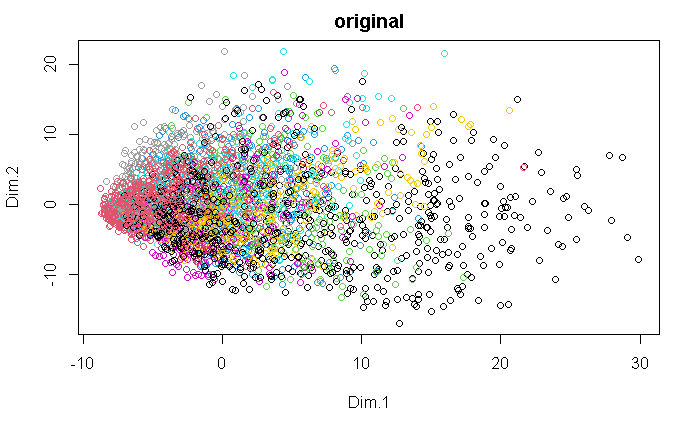

```r
pred.rmix = as.vector(predictions["partition"])
pred.mclust = as.vector(res.mclust$class)
true_values = as.vector(y_data[,1])

plot(res.PCA$ind$coord,col=true_values, main = "original")
```

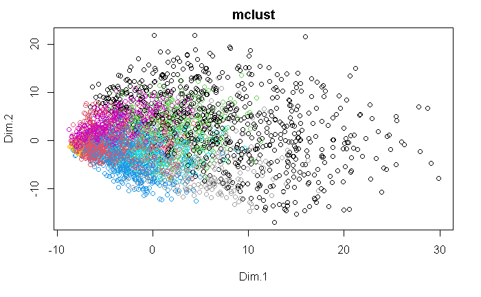

```r
plot(res.PCA$ind$coord,col=pred.mclust, main = "mclust")
```

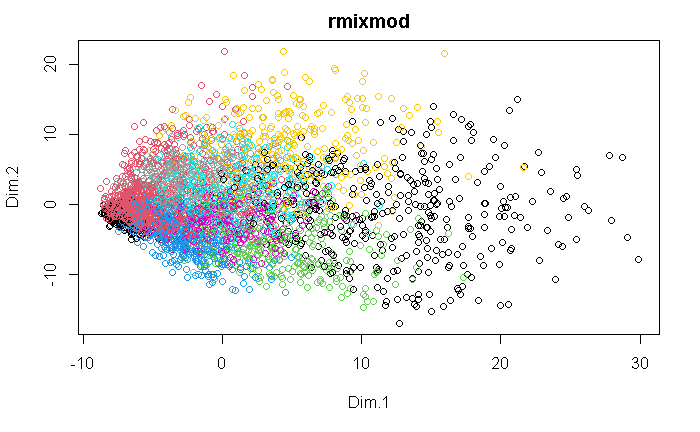

```r
plot(res.PCA$ind$coord,col=pred.rmix, main = "rmixmod")
```

# Q8 : comparer les partitions de mclust et rmixmod

Les resultats des deux packages sont plus ou moins similaire sur la plus part des clusters (exemple cluster 5 de mclust plus ou moin égale au cluster 6 de rmixmod), avec cependant quelques differences sur certains cluster ou il semble y’avoir un désaccord, par exemple le cluster 10 de mclust est répartie sur deux cluster pour rmixmod (2 et 10).

```r
table(pred.rmix,pred.mclust)
```

```
         pred.mclust
pred.rmix   1   2   3   4   5   6   7   8   9  10
       1    1   0  28   0   0   0   0   0 354   0
       2    0   0   0  11   0 107   0   0   0 265
       3    0   0  17  32   0   0   0 347   8   1
       4    0  18   0 349   0   2   0   1   0   8
       5    1   0 351  83   0   4   0   4   1   0
       6    0   0  26  19 239   3   5   2   6   0
       7  192   0  24   2   0   1   0  64  29   0
       8   21   0   1   6   0 237   0   8   2  59
       9    0 148   0  12   0   1 180   0   0   0
       10  82   0   0   6   0   7   0   0   0 120
```

# Q9: MclustDR

MclustDR est une methode de reduction de la dimension linéaire utilisé afin de visualiser le resultat de clustering ou de classification obtenue par des mélanges gaussiens.

```r
res.mclustdr = MclustDR(res.mclust)
summary(res.mclustdr)
```

```
-----------------------------------------------------------------
Dimension reduction for model-based clustering and classification
-----------------------------------------------------------------

Mixture model type: Mclust (VVV, 10)

Clusters   n
      1  297
      2  166
      3  447
      4  520
      5  239
      6  362
      7  185
      8  426
      9  400
      10 453

Estimated basis vectors:
            Dir1      Dir2      Dir3      Dir4     Dir5     Dir6      Dir7      Dir8
Dim.1 -0.0459613 -0.147374  0.479977 -0.056483  0.45717 -0.22659 -0.020211  0.257578
Dim.2 -0.0265441  0.688769  0.326731 -0.182791 -0.04021  0.08922 -0.319565 -0.080094
Dim.3  0.3547701 -0.117013  0.224079 -0.077789 -0.64954 -0.17510 -0.096612  0.366573
Dim.4  0.2128468 -0.310185  0.057416  0.196716  0.20006  0.62800 -0.568427  0.105806
Dim.5  0.0365502  0.122074 -0.771676 -0.261290  0.29254 -0.29944 -0.390667  0.414866
Dim.6  0.0077159  0.224619 -0.060325 -0.263016  0.09695  0.62488  0.581184  0.581385
Dim.7 -0.8206454  0.011174  0.024885  0.341510 -0.41415  0.02640 -0.203800  0.445091
Dim.8  0.3887969  0.573141 -0.098071  0.815212  0.24688 -0.18655  0.181922  0.270997

               Dir1    Dir2     Dir3     Dir4     Dir5     Dir6     Dir7      Dir8
Eigenvalues  1.7841  1.0608  0.90216  0.69904  0.63251  0.49205  0.36242   0.29502
Cum. %      28.6456 45.6780 60.16344 71.38743 81.54324 89.44380 95.26296 100.00000
```

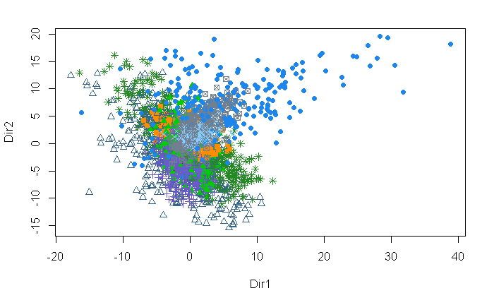

```r
plot(res.mclustdr, what="scatterplot")
```

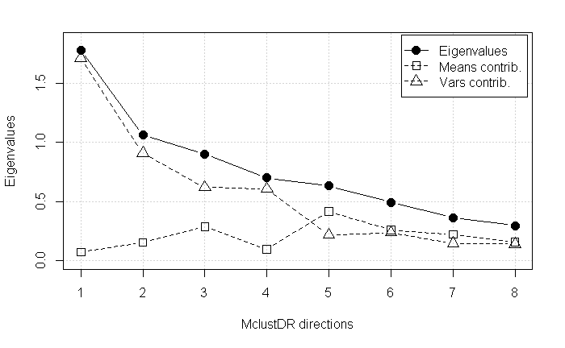

```r
plot(res.mclustdr, what="evalues")
```

# Q10: Comparaison des different algorithmes

D’apres les resultats obtenu, on remarque que le nombre de cluster optimal est bel et bien 10, aussi, rmixmod semble obtenir les meilleurs resultats sur l’ensemble des methodes, les methodes de melanges en general semble obtenir de bien meilleurs resultats comparé aux algorithmes de clustering standard.

Si nous comparons Mclust à Rmixmod, on voit que rmixmod semble plus performant sur ce dataset, cependant, il dépasse mclust de peu et reste instable et requiert plusieurs test afin de fonctionner convenablement.

Rmixmod semble plus performant lorsque que l’on a plus de données (l’initialisation smallEM semble devenir plus efficace)

```r
library(clusterSim)
library(aricode)

pred.rmix = as.vector(predictions["partition"])
pred.mclust = as.vector(res.mclust$class)
true_values = as.vector(y_data[,1])


print(paste("Rmixmod taux de mal classé : ", 1- comparing.Partitions(pred.rmix,true_values)))
```

```
[1] "Rmixmod taux de mal classé :  0.454023250252885"
```

```r
print(paste("Mclust taux de mal classé : ", 1-comparing.Partitions(pred.mclust,true_values)))
```

```
[1] "Mclust taux de mal classé :  0.504412804839565"
```

```r
print(paste("cah ward taux de mal classé : ", 1-comparing.Partitions(res_cah_ward$Best.partition,true_values)))
```

```
[1] "cah ward taux de mal classé :  0.807796374029826"
```

```r
print(paste("cah average taux de mal classé : ", 1-comparing.Partitions(res_cah_average$Best.partition,true_values)))
```

```
[1] "cah average taux de mal classé :  0.829657719048832"
```

```r
print(paste("cah complete de mal classé : ", 1-comparing.Partitions(res_cah_complete$Best.partition,true_values)))
```

```
[1] "cah complete de mal classé :  0.815660087788455"
```

```r
print(paste("cah singe  taux de mal classé : ", 1-comparing.Partitions(res_cah_single$Best.partition,true_values)))
```

```
[1] "cah singe  taux de mal classé :  0.907053301749067"
```

```r
print(paste("kmeans  taux de mal classé : ", 1-comparing.Partitions(res_cah_kmeans$Best.partition,true_values)))
```

```
[1] "kmeans  taux de mal classé :  0.831125477698684"
```

```r
print("")
```

```
[1] ""
```

```r
print("")
```

```
[1] ""
```

```r
print(paste("Rmixmod ARI : ",adjustedRandIndex(pred.rmix,true_values)))
```

```
[1] "Rmixmod ARI :  0.391013767275009"
```

```r
(paste("Mclust ARI : ",adjustedRandIndex(pred.mclust,true_values)))
```

```
[1] "Mclust ARI :  0.353120039947371"
```

```r
print(paste("cah_ward ARI : ",adjustedRandIndex(res_cah_ward$Best.partition,true_values)))
```

```
[1] "cah_ward ARI :  0.157826678894605"
```

```r
(paste("cah_average ARI : ",adjustedRandIndex(res_cah_average$Best.partition,true_values)))
```

```
[1] "cah_average ARI :  0.0354288822666475"
```

```r
(paste("cah_complete ARI : ",adjustedRandIndex(res_cah_complete$Best.partition,true_values)))
```

```
[1] "cah_complete ARI :  0.0139560955342483"
```

```r
(paste("cah_single ARI : ",adjustedRandIndex(res_cah_single$Best.partition,true_values)))
```

```
[1] "cah_single ARI :  1.2815712798945e-06"
```

```r
(paste("kmeans ARI : ",adjustedRandIndex(res_cah_kmeans$Best.partition,true_values)))
```

```
[1] "kmeans ARI :  0.0828822838926144"
```

```r
print("")
```

```
[1] ""
```

```r
print("")
```

```
[1] ""
```

```r
print(paste("Rmixmod NMI : ",NMI(pred.rmix,true_values)))
```

```
[1] "Rmixmod NMI :  0.516446546046413"
```

```r
(paste("Mclust NMI : ",NMI(pred.mclust,true_values)))
```

```
[1] "Mclust NMI :  0.501377309632971"
```

```r
print(paste("cah_ward NMI : ",NMI(res_cah_ward$Best.partition,true_values)))
```

```
[1] "cah_ward NMI :  0.217363829157855"
```

```r
(paste("cah_average NMI : ",NMI(res_cah_average$Best.partition,true_values)))
```

```
[1] "cah_average NMI :  0.11309225010549"
```

```r
(paste("cah_complete NMI : ",NMI(res_cah_complete$Best.partition,true_values)))
```

```
[1] "cah_complete NMI :  0.0493156564666572"
```

```r
(paste("cah_single NMI : ",NMI(res_cah_single$Best.partition,true_values)))
```

```
[1] "cah_single NMI :  0.000287356751466477"
```

```r
(paste("kmeans NMI : ",NMI(res_cah_kmeans$Best.partition,true_values)))
```

```
[1] "kmeans NMI :  0.116055477676941"
```

# Q11: TSNE

```r
library(Rtsne)
tsne_res <- Rtsne(x_data[,1:784], dims = 2, perplexity=30, verbose=TRUE, max_iter = 2500)
```

[output not shown]

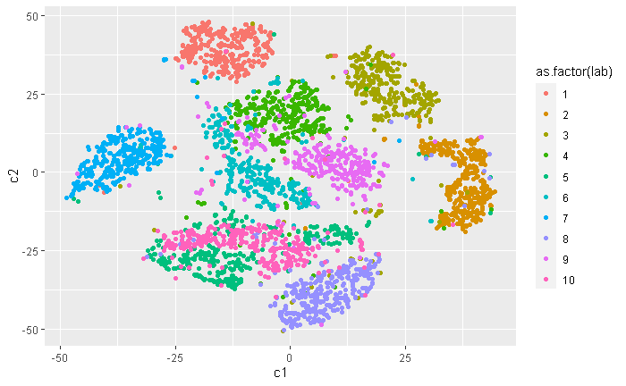

```r
tnse_df = as.data.frame(tsne_res$Y)
tnse_df = cbind(tnse_df,true_values, pred.rmix, pred.mclust)
names(tnse_df) = c("c1", "c2", "lab", "rmix", "mclust")
ggplot(tnse_df, aes(c1, y=c2, color=as.factor(lab)) ) + geom_point()
```

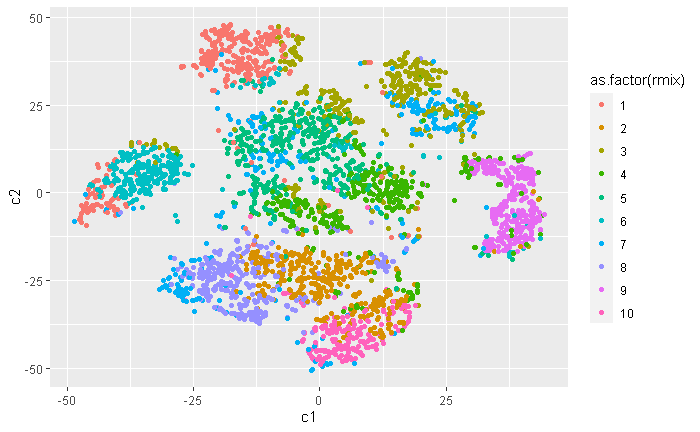

```r
ggplot(tnse_df, aes(c1, y=c2, color=as.factor(rmix)) ) + geom_point()
```

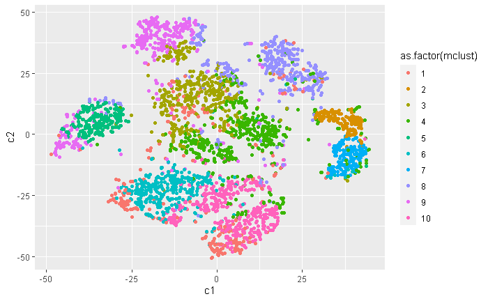

```r
ggplot(tnse_df, aes(c1, y=c2, color=as.factor(mclust))) + geom_point()
```

```r
library(h2o)

h2o.init()
```

[output not shown]

```
Your H2O cluster version is too old (3 months and 20 days)!
Please download and install the latest version from http://h2o.ai/download/
```

```r
ae_model <- h2o.deeplearning(x=c(1:784),
                                  model_id="ae_model",
                                  training_frame=as.h2o(x_data[,1:784]),
                                  activation="Tanh",
                                  ignore_const_cols=FALSE,
                                  autoencoder=TRUE,
                                  hidden=c(32, 16, 8, 16,32),
                                  epochs=50,
                                  reproducible=T,
                                  seed=1)
```

```r
features <- h2o.deepfeatures(ae_model, as.h2o(x_data[,1:784]), layer=3)
```

```r
set.seed(1)
res.mclust=Mclust(features, G = 1:10)
```

```
fitting ...
```

```r
summary(res.mclust$BIC)
```

```
Best BIC values:
            VVV,10       VVV,9      VVV,8
BIC      -11033.16 -11447.6008 -11875.191
BIC diff      0.00   -414.4437   -842.034
```

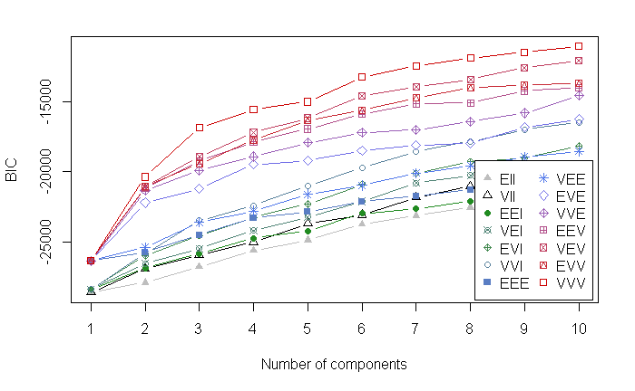

```r
plot(res.mclust,what="BIC")
```

```r
names(res.mclust)
```

```
 [1] "call"           "data"           "modelName"      "n"              "d"              "G"
 [7] "BIC"            "loglik"         "df"             "bic"            "icl"            "hypvol"
[13] "parameters"     "z"              "classification" "uncertainty"
```

```r
table(res.mclust$class,as.vector(y_data[,1]))
```

```
       1   2   3   4   5   6   7   8   9  10
  1    1   4 312  13   3   1   2  11   5   1
  2    0 166   0   0   0   0   0   0   0   0
  3    2   0   0   0   0   1 232   0   0   0
  4    2   4   6 289   0 130   0   1  60   8
  5    0  27   5   0  95  23   1 113  15  60
  6  289   0   5   4   9   9  54   1  12   4
  7    0   0   5   4 204   3   1  47   3 172
  8    0 180   0   1   0   0   0   0   0   1
  9   51  12  15  44  12 146  53   5 244   8
  10   0   0   1   2  18   2   0 186   2  93
```

```r
res.mclust$modelName
```

```
[1] "VVV"
```

```r
adjustedRandIndex(res.mclust$class,as.vector(y_data[,1]))
```

```
[1] 0.4233977
```

```r
res.mixmod = mixmodCluster(data=as.data.frame(features),nbCluster=1:10,models=mixmodGaussianModel(listModels = c("Gaussian_p_Lk_Ck", "Gaussian_pk_Lk_Ck")))
```

```r
predictions= mixmodPredict(as.data.frame(features), classificationRule=res.mixmod["bestResult"])
```

```r
library(clusterSim)
library(aricode)

pred.rmix = as.vector(predictions["partition"])
pred.mclust = as.vector(res.mclust$class)
true_values = as.vector(y_data[,1])

print(paste("Rmixmod taux de bien classé : ", comparing.Partitions(pred.rmix,true_values)))
```

```
[1] "Rmixmod taux de bien classé :  0.592500717153903"
```

```r
print(paste("Mclust taux de bien classé : ", comparing.Partitions(pred.mclust,true_values)))
```

```
[1] "Mclust taux de bien classé :  0.54245791210048"
```

```r
print(paste("Rmixmod ARI : ",adjustedRandIndex(pred.rmix,true_values)))
```

```
[1] "Rmixmod ARI :  0.472152407583782"
```

```r
(paste("Mclust ARI : ",adjustedRandIndex(pred.mclust,true_values)))
```

```
[1] "Mclust ARI :  0.423397687997742"
```

```r
print(paste("Rmixmod NMI : ",NMI(pred.rmix,true_values)))
```

```
[1] "Rmixmod NMI :  0.585558103079181"
```

```r
(paste("Mclust NMI : ",NMI(pred.mclust,true_values)))
```

```
[1] "Mclust NMI :  0.566494696839776"
```

[output not shown]